# Clustering Analyses: Partitioning

Bryn Bandt-law

2/9/2021

The ‘knit’ chunck will allow us to ‘knit’ the Rmarkdown to a pdf for submission

**Clustering Technique: Partitioning**

read in Group 4 merged data set from out github folder

```r
library(readr)

link='https://raw.githubusercontent.com/Public-Policy-COVID/students_merge/main/Merged_data.csv'

data = read.csv(link)
```

reset indexes to R format:

```r
row.names(data)=NULL
```

**Partitioning**

-We will request a particular number of clusters to the algorithm. The algorithm will put every case in one of those clusters and utliers will affect output

For clustering, the variables need to be numeric. Change non-numeric variables (Deaths_COVID & Deaths_total) with integers to numeric.

```r
data$Deaths_COVID<-as.numeric(data$Deaths_COVID)

data$Deaths_total<-as.numeric(data$Deaths_total)
```

1. select variables to use for clustering

```r
dfClus=data[,c('Number_of_beds','mask_score','Deaths_COVID','Deaths_total','Number_of_hospitals', "black_total_pct","white_total_pct")]

summary(dfClus)
```

```
##  Number_of_beds      mask_score     Deaths_COVID   Deaths_total
##  Min.   :    0.0   Min.   :2.470   Min.   :   0   Min.   :    0
##  1st Qu.:   25.0   1st Qu.:3.301   1st Qu.:   0   1st Qu.:    0
##  Median :  131.0   Median :3.464   Median :  22   Median :  637
##  Mean   :  885.4   Mean   :3.428   Mean   : 206   Mean   : 2896
##  3rd Qu.:  553.0   3rd Qu.:3.591   3rd Qu.: 128   3rd Qu.: 2537
##  Max.   :26672.0   Max.   :3.822   Max.   :8034   Max.   :75463
##  Number_of_hospitals black_total_pct  white_total_pct
##  Min.   :  0         Min.   : 0.000   Min.   :49.28
##  1st Qu.:  1         1st Qu.: 0.770   1st Qu.:82.16
##  Median :  2         Median : 1.260   Median :88.64
##  Mean   :  5         Mean   : 2.318   Mean   :85.50
##  3rd Qu.:  4         3rd Qu.: 2.620   3rd Qu.:91.84
##  Max.   :112         Max.   :14.770   Max.   :96.13
```

2. rescale units

```r
dfClus=scale(dfClus)
summary(dfClus)
```

```
##  Number_of_beds      mask_score       Deaths_COVID      Deaths_total
##  Min.   :-0.3334   Min.   :-4.2726   Min.   :-0.2704   Min.   :-0.37704
##  1st Qu.:-0.3240   1st Qu.:-0.5659   1st Qu.:-0.2704   1st Qu.:-0.37704
##  Median :-0.2841   Median : 0.1612   Median :-0.2415   Median :-0.29411
##  Mean   : 0.0000   Mean   : 0.0000   Mean   : 0.0000   Mean   : 0.00000
##  3rd Qu.:-0.1252   3rd Qu.: 0.7277   3rd Qu.:-0.1024   3rd Qu.:-0.04674
##  Max.   : 9.7118   Max.   : 1.7581   Max.   :10.2736   Max.   : 9.44771
##  Number_of_hospitals black_total_pct   white_total_pct
##  Min.   :-0.44686    Min.   :-0.8976   Min.   :-3.8920
##  1st Qu.:-0.35749    1st Qu.:-0.5994   1st Qu.:-0.3585
##  Median :-0.26812    Median :-0.4097   Median : 0.3379
##  Mean   : 0.00000    Mean   : 0.0000   Mean   : 0.0000
##  3rd Qu.:-0.08937    3rd Qu.: 0.1169   3rd Qu.: 0.6818
##  Max.   : 9.56284    Max.   : 4.8214   Max.   : 1.1428
```

3. rename subset indexes and verify input:

```r
row.names(dfClus)=data$Location
head(dfClus)
```

```
##              Number_of_beds mask_score Deaths_COVID Deaths_total
## Alameda_CA        1.0476322  1.0666781    0.4816583   1.04310240
## Alpine_CA        -0.3334445 -0.6640201   -0.2703586  -0.37704284
## Amador_CA        -0.3138601 -0.1465949   -0.2296736  -0.32301275
## Butte_CA         -0.1251719 -0.2090427   -0.1378042  -0.07590643
## Calaveras_CA     -0.3240289 -0.6104934   -0.2546096  -0.32691854
## Colusa_CA        -0.3153666  0.1790262   -0.2546096  -0.36194046
##              Number_of_hospitals black_total_pct white_total_pct
## Alameda_CA            1.51932965       3.3732540     -3.89196747
## Alpine_CA            -0.44686166      -0.7620594     -1.88666366
## Amador_CA            -0.35748933       0.1401204      0.44640953
## Butte_CA              0.08937233      -0.1618969      0.01654805
## Calaveras_CA         -0.35748933      -0.4794022      0.58611451
## Colusa_CA            -0.35748933      -0.3903458      0.60223432
```

4. set random seed for replicability of results

```r
set.seed(999)
```

5. designate distance method and compute distance matrix

```r
library(cluster)
dfClus_D=cluster::daisy(x=dfClus)
```

6. For the partitioning technique, we need to indicate the number of clusters required

```r
NumCluster=4
res.pam = pam(x=dfClus_D,
              k = NumCluster,
              cluster.only = F)
```

g.Append the clustering results to the dataframe (data)

```r
data$pam=as.factor(res.pam$clustering)
```

8. query the data frame (we will create a table to see the number of counties per cluster and will look at King, County, WA)

```r
table(data$pam)
```

```
##
##  1  2  3  4
## 14 50 39 30
```

```r
data[data$Location=="King_WA",'pam']
```

```
## [1] 1
## Levels: 1 2 3 4
```

**Evaluate results**

(a)create average sillohuetes

```r
library(factoextra)
```

```
##   cluster size ave.sil.width
## 1       1   14         -0.02
## 2       2   50          0.26
## 3       3   39          0.41
## 4       4   30          0.07
```

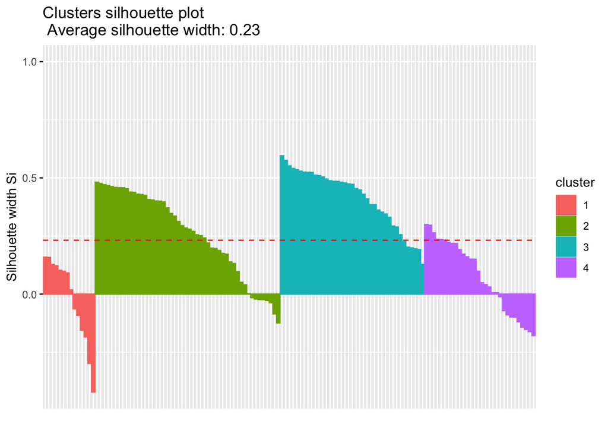

```r
fviz_silhouette(res.pam)
```

- the average silhouette width is .23

2. detect anomolies: -save individual silhouettes

```r
pamEval=data.frame(res.pam$silinfo$widths)
head(pamEval)
```

```
##                   cluster neighbor sil_width
## Alameda_CA              1        4 0.1591567
## San Bernardino_CA       1        4 0.1579688
## Los Angeles_CA          1        4 0.1277071
## San Diego_CA            1        4 0.1215627
## Sacramento_CA           1        4 0.1027119
## King_WA                 1        4 0.0985324
```

```
  -request negative silhouettes.
  A negative silhouettes indicates that the item
  is poorly clustered
```

```r
pamEval[pamEval$sil_width<0,]
```

```
##                  cluster neighbor   sil_width
## Solano_CA              1        4 -0.06312941
## San Francisco_CA       1        4 -0.09158907
## Santa Clara_CA         1        4 -0.15525012
## Contra Costa_CA        1        4 -0.18405269
## San Joaquin_CA         1        4 -0.29794661
## Fresno_CA              1        4 -0.42095642
## Wheeler_OR             2        3 -0.01532344
## Grant_WA               2        3 -0.02085607
## Alpine_CA              2        4 -0.02335024
## Grant_OR               2        3 -0.02363649
## Cowlitz_WA             2        3 -0.02718744
## Franklin_WA            2        3 -0.03694608
## Kittitas_WA            2        3 -0.08484523
## Josephine_OR           2        3 -0.12406058
## Inyo_CA                4        3 -0.01091712
## Santa Barbara_CA       4        3 -0.07124933
## Sonoma_CA              4        3 -0.08919528
## Humboldt_CA            4        3 -0.09860057
## Imperial_CA            4        3 -0.09878916
## Whitman_WA             4        3 -0.11925089
## Lake_CA                4        3 -0.14186724
## Placer_CA              4        3 -0.15197878
## Island_WA              4        3 -0.16148989
## Clark_WA               4        3 -0.17829522
```